# 空間分析 作業七

電機四 B05901013 張景皓

5/2/2020

## Nearest Neighbor Analysis (Taichung v.s. Changhua)

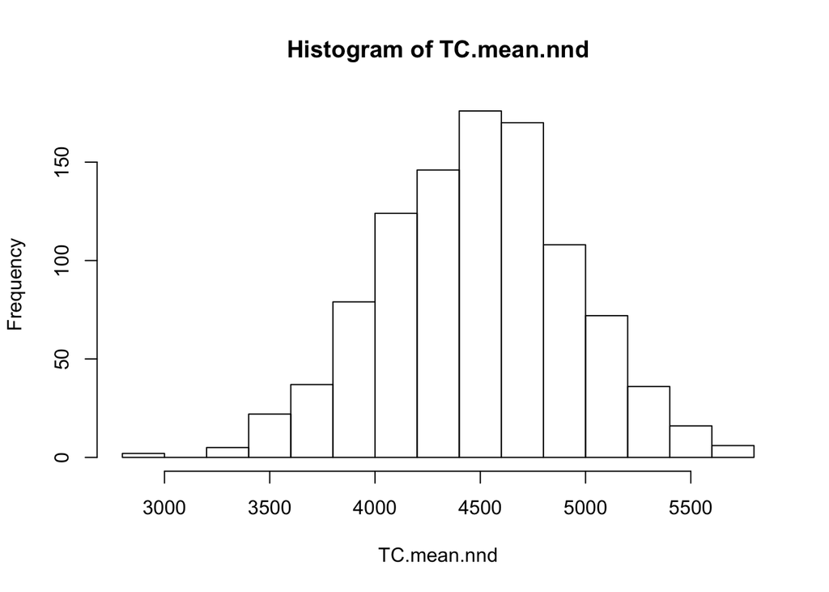

```r
Mazu.TC.nnd <- nndist(X = Mazu.TC.ppp, k = 1);
Mazu.CH.nnd <- nndist(X = Mazu.CH.ppp, k = 1);

TC.r.obs <- mean(Mazu.TC.nnd); #2838.755
TC.r.exp <- 0.5 / sqrt(nrow(Mazu.TC) / Taichung@polygons[[1]]@area); #4039.533
TC.r.scale <- TC.r.obs / TC.r.exp; #0.703
TC.se <- 0.26136 * sqrt(Taichung@polygons[[1]]@area) / nrow(Mazu.TC); #362.127
TC.z <- (TC.r.obs - TC.r.exp) / TC.se; #-3.316

CH.r.obs <- mean(Mazu.CH.nnd); #3464.291
CH.r.exp <- 0.5 / sqrt(nrow(Mazu.CH) / Changhua@polygons[[1]]@area); #2997.987
CH.r.scale <- CH.r.obs / CH.r.exp; #1.155
CH.se <- 0.26136 * sqrt(Changhua@polygons[[1]]@area) / nrow(Mazu.CH); #281.461
CH.z <- (CH.r.obs - CH.r.exp) / CH.se; #1.657

TC.mean.nnd <- c();
for (i in 1:999) {
  TC.mean.nnd[i] <- mean(nndist(X = rpoint(34, win = Windows.TC), k = 1));
}
TC.r.exp5 <- quantile(TC.mean.nnd, 0.05, type = 3); #5%
TC.r.exp95 <- quantile(TC.mean.nnd, 0.95, type = 3); #95%

CH.mean.nnd <- c();
for (j in 1:999) {
  CH.mean.nnd[j] <- mean(nndist(X = rpoint(31, win = Windows.CH), k = 1));
}
CH.r.exp5 <- quantile(CH.mean.nnd, 0.05, type = 3); #5%
CH.r.exp95 <- quantile(CH.mean.nnd, 0.95, type = 3); #95%

hist.TC <- hist(TC.mean.nnd);
```

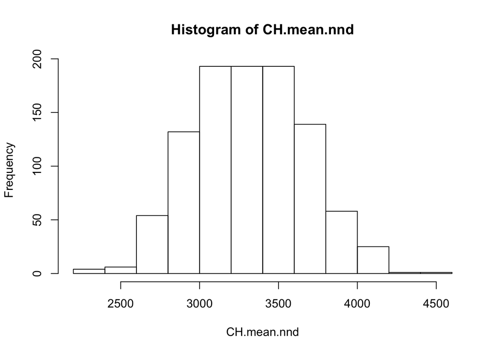

```r
hist.CH <- hist(CH.mean.nnd);
```

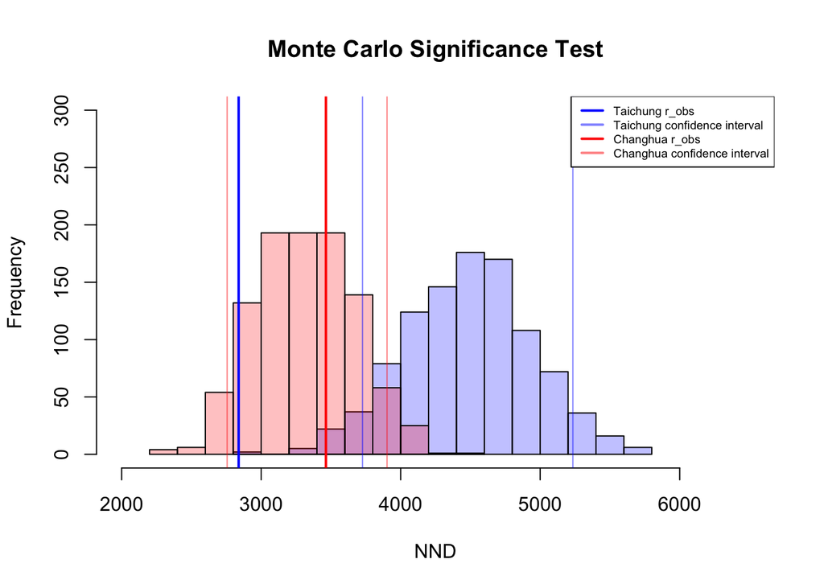

```r
plot(hist.TC, col = rgb(0, 0, 1, 0.25), xlim = c(2000, 6500), ylim = c(0, 300), main = "Monte Carlo Significance Test", xlab = "NND");
plot(hist.CH, col = rgb(1, 0, 0, 0.25), add = TRUE);
abline(v = TC.r.obs, col = "blue", lwd = 2);
abline(v = CH.r.obs, col = "red", lwd = 2);
abline(v = TC.r.exp5, col = rgb(0, 0, 1, 0.5), lwd = 1);
abline(v = TC.r.exp95, col = rgb(0, 0, 1, 0.5), lwd = 1);
abline(v = CH.r.exp5, col = rgb(1, 0, 0, 0.5), lwd = 1);
abline(v = CH.r.exp95, col = rgb(1, 0, 0, 0.5), lwd = 1);
legend("topright", c("Taichung r_obs", "Taichung confidence interval", "Changhua r_obs", "Changhua confidence interval"), col = c("blue", rgb(0, 0, 1, 0.5), "red", rgb(1, 0, 0, 0.5)), lwd = 2, cex = 0.6);
```

According to observational mean distance and expected mean distance of random distribution of Taichung Mazu temples, the difference of the two ($d = \bar r_\mathrm{obs} - \bar r_\mathrm{exp}$) is less than 0 and the ratio of the two ($R = \frac{r_\mathrm{obs}}{r_\mathrm{exp}}$) is less than 1. In conclusion, the distribution of Mazu temples of Taichung City is clustered. Whereas the difference of the observational mean distance and expected mean distance of random distribution of Changhua Mazu temples is greater than 0 and the ratio of the two is greater than 1, indicating Mazu temples of Changhua County approximates random distribution.

### Monte Carlo significance test for Taichung Mazu temples

$H_0: \mathrm{Temples\ of\ Taichung\ are\ randomly\ distributed.}$  
$H_1: \mathrm{Temples\ of\ Taichung\ are\ not\ randomly\ distributed.}$  
The test is carried out at 90% confidence level.

The observational mean distance does not lie within the confindence interval bounded by the 5th and 95th percentile of mean distances created by the Monte Carlo simulation. Therefore, the test fails and $H_0$ is rejected. Alternatively, $H_1$ which states the point pattern is not random is accepted. Since the observational mean distance locates on the left from the 5th percentile, the difference is significant and the distribution is clustered.

### Monte Carlo significance test for Changhua Mazu temples

$H_0: \mathrm{Temples\ of\ Changhua\ are\ randomly\ distributed.}$  
$H_1: \mathrm{Temples\ of\ Changhua\ are\ not\ randomly\ distributed.}$  
The test is carried out at 90% confidence level.

The observational mean distance lies within the confindence interval bounded by the 5th and 95th percentile of mean distances created by the Monte Carlo simulation. Therefore, the test passes and $H_0$ is accepted.

## K-order Nearest Neightbor Indices (Taichung v.s. Changhua)

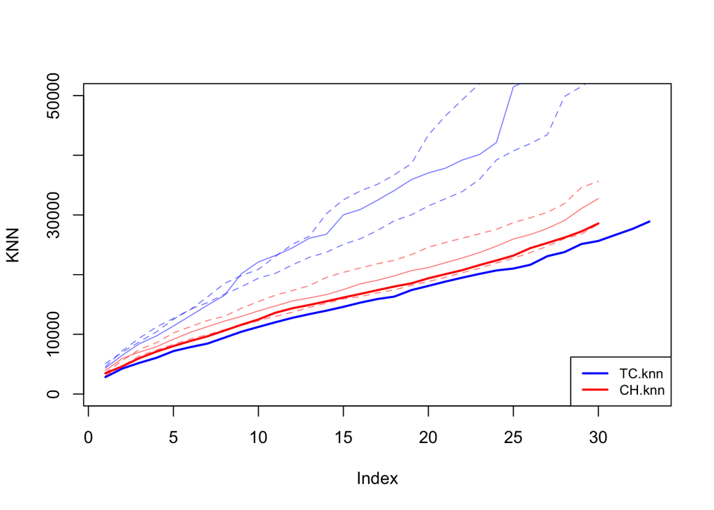

```r
Mazu.TC.knn <- apply(nndist(X = Mazu.TC.ppp, k = 1:33), 2, FUN = mean);
Mazu.CH.knn <- apply(nndist(X = Mazu.CH.ppp, k = 1:30), 2, FUN = mean);

TC.mean <- c();
TC.knn <- list();
for (k in 1:999) {
  random.points <- rpoint(34, win = Windows.TC);
  TC.mean[k] <- mean(nndist(X = random.points, k = 1:33));
  TC.knn[[k]] <- apply(nndist(X = random.points, k = 1:33), 2, FUN = mean);
}

CH.mean <- c();
CH.knn <- list();
for (m in 1:999) {
  random.points <- rpoint(31, win = Windows.CH);
  CH.mean[m] <- mean(nndist(X = random.points, k = 1:30));
  CH.knn[[m]] <- apply(nndist(X = random.points, k = 1:30), 2, FUN = mean);
}

plot(Mazu.TC.knn, type = "l", col = "blue", ylab = "KNN", lwd = 2, ylim = c(0, 50000));
lines(Mazu.CH.knn, col = "red", lwd = 2);

lines(TC.knn[[which(TC.mean == quantile(TC.mean, 0.05, type = 3))]], type = "l", col = rgb(0, 0, 1, 0.5), lty = "dashed");
lines(TC.knn[[which(TC.mean == quantile(TC.mean, 0.5, type = 3))]], type = "l", col = rgb(0, 0, 1, 0.5));
lines(TC.knn[[which(TC.mean == quantile(TC.mean, 0.95, type = 3))]], type = "l", col = rgb(0, 0, 1, 0.5), lty = "dashed");

lines(CH.knn[[which(CH.mean == quantile(CH.mean, 0.05, type = 3))]], type = "l", col = rgb(1, 0, 0, 0.5), lty = "dashed");
lines(CH.knn[[which(CH.mean == quantile(CH.mean, 0.5, type = 3))]], type = "l", col = rgb(1, 0, 0, 0.5));
lines(CH.knn[[which(CH.mean == quantile(CH.mean, 0.95, type = 3))]], type = "l", col = rgb(1, 0, 0, 0.5), lty = "dashed");

legend("bottomright", c("TC.knn", "CH.knn"), col = c("blue", "red"), lwd = 2, cex = 0.8);
```

### Significance test of K-NNI of Taichung Mazu temples

$H_0: 5^\mathrm{th} \mathrm{percentile\ KNNI} \leq \mathrm{KNNI}_{obs} \leq 95^\mathrm{th} \mathrm{percentile\ KNNI}$  
$H_1: 5^\mathrm{th} \mathrm{percentile\ KNNI} \geq \mathrm{KNNI}_{obs} \mathrm{\ or\ } \mathrm{KNNI}_{obs} \geq 95^\mathrm{th} \mathrm{percentile\ KNNI}$  
The test is carried out at 90% confidence level.

According to the plot of K-NNI of Taichung Mazu temples, the observational K-NNI does not belong to the confindence envelope between the 5th/95th percentile of K-NNI. Therefore, the test fails and $H_0$ is rejected. Alternatively, $H_1$ which states the point pattern is not random is accepted. Since the observational K-NNI lies below the 5th percentile of K-NNI, indicating the difference is significant and the distribution is clustered.

### Significance test of K-NNI of Changhua Mazu temples

$H_0: 5^\mathrm{th} \mathrm{percentile\ KNNI} \leq \mathrm{KNNI}_{obs} \leq 95^\mathrm{th} \mathrm{percentile\ KNNI}$  
$H_1: 5^\mathrm{th} \mathrm{percentile\ KNNI} \geq \mathrm{KNNI}_{obs} \mathrm{\ or\ } \mathrm{KNNI}_{obs} \geq 95^\mathrm{th} \mathrm{percentile\ KNNI}$  
The test is carried out at 90% confidence level.

According to the plot of K-NNI of Changhua Mazu temples, the observational K-NNI mainly lies within the confindence envelope between the 5th/95th percentile of K-NNI but close to the 5th percentile plot. Therefore, the test passes and $H_0$ is accepted.

## G function (Taichung v.s. Changhua)

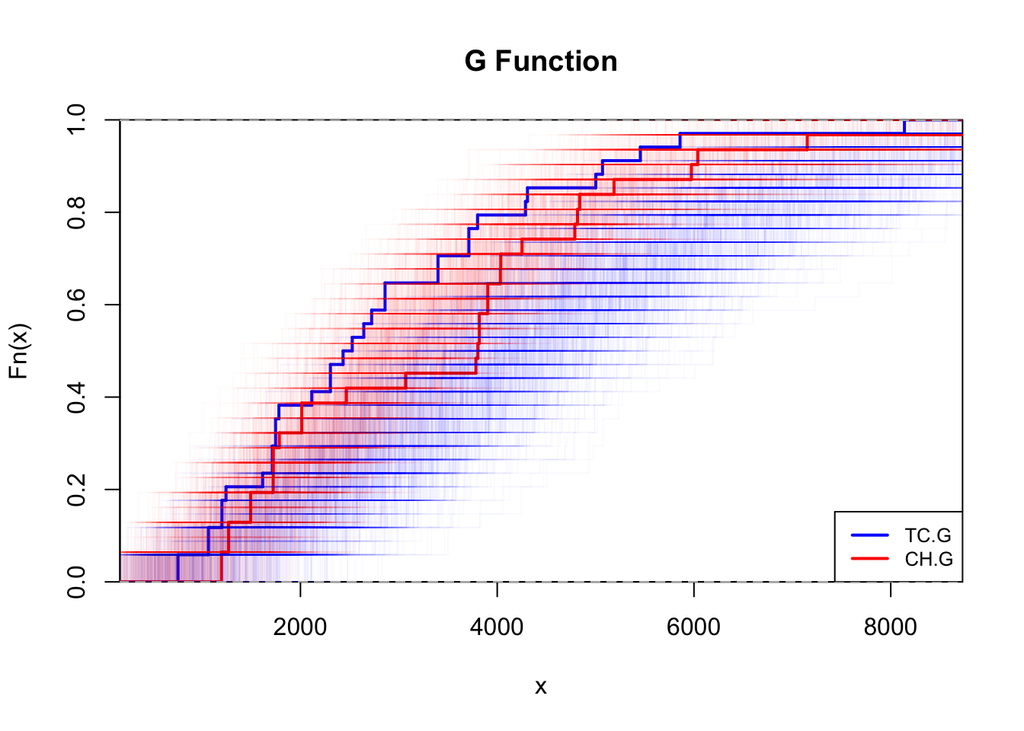

```r
TC.G <- ecdf(Mazu.TC.nnd);
CH.G <- ecdf(Mazu.CH.nnd);
plot(TC.G, col = "blue", cex = 0, verticals = TRUE, xaxs = "i", yaxs = "i", lwd = 2, main = "G Function");
plot(CH.G, col = "red", add = TRUE, cex = 0, verticals = TRUE, xaxs = "i", yaxs = "i", lwd = 2);

for (n in 1:999) {
  TC.nnd <- nndist(X = rpoint(34, win = Windows.TC), k = 1);
  TC.g <- ecdf(TC.nnd);
  CH.nnd <- nndist(X = rpoint(31, win = Windows.CH), k = 1);
  CH.g <- ecdf(CH.nnd);
  plot(TC.g, col = rgb(0, 0, 1, 0.02), add = TRUE, cex = 0, verticals = TRUE, xaxs = "i", yaxs = "i");
  plot(CH.g, col = rgb(1, 0, 0, 0.02), add = TRUE, cex = 0, verticals = TRUE, xaxs = "i", yaxs = "i");
}

legend("bottomright", c("TC.G", "CH.G"), col = c("blue", "red"), lwd = 2, cex = 0.8);
```

### Significance test of G Function (Changhua)

H0: The G function plot of Changhua Mazu temples lies within the envelope of G function plots of the random distribution, indicating the temples are randomly distributed.  
H1: The G function plot of Changhua Mazu temples does not lie within the envelope of G function plots of the random distributioin, indicating the temples are not randomly distributed.

According to the plot, the G function plot of Changhua Mazu temples lies within the envelope but close to the lower bound. Therefore, the test passes and $H_0$ is accepted.

## 論文研讀摘要與個人心得